# R Notebook

# Instalaci?n de Paquetes

```r
install.packages(c("arules","arulesViz","TSP"),
                 dependencies = c("Depends"))
```

# Ejemplo: Groceries

```r
#_______________________________________________________
# Paso 1: Obtener y procesar la base de datos
#_______________________________________________________

# Usando librer?a arules
library(arules)
data("Groceries")
head(Groceries)
```

```
transactions in sparse format with
 6 transactions (rows) and
 169 items (columns)
```

```r
summary(Groceries)
```

```
transactions as itemMatrix in sparse format with
 9835 rows (elements/itemsets/transactions) and
 169 columns (items) and a density of 0.02609146

most frequent items:
      whole milk other vegetables       rolls/buns
            2513             1903             1809
            soda           yogurt          (Other)
            1715             1372            34055

element (itemset/transaction) length distribution:
sizes
   1    2    3    4    5    6    7    8    9   10   11   12   13
2159 1643 1299 1005  855  645  545  438  350  246  182  117   78
  14   15   16   17   18   19   20   21   22   23   24   26   27
  77   55   46   29   14   14    9   11    4    6    1    1    1
  28   29   32
   1    3    1

   Min. 1st Qu.  Median    Mean 3rd Qu.    Max.
  1.000   2.000   3.000   4.409   6.000  32.000

includes extended item information - examples:
```

|  | labels | level2 | level1 |
| --- | --- | --- | --- |
| 1 | frankfurter | sausage | meat and sausage |
| 2 | sausage | sausage | meat and sausage |
| 3 | liver loaf | sausage | meat and sausage |

```r
#labels(Groceries)
```

```r
help(Groceries)
```

El conjunto de Groceries contiene informacion de un mes de un tienda de transacciones que son obtenido a traves de un outlet loca

```r
# Importando de un archivo .csv y convirtiendo a transacciones
#groceries <- read.transactions(file = file.choose(),
#                               sep = ",",
#                               format = "basket")
groceries <- read.transactions("groceries.csv",
                               sep = ",",
                               format = "basket")
```

```r
groceries
```

```
transactions in sparse format with
 9835 transactions (rows) and
 169 items (columns)
```

```r
summary(groceries)
```

```
transactions as itemMatrix in sparse format with
 9835 rows (elements/itemsets/transactions) and
 169 columns (items) and a density of 0.02609146

most frequent items:
      whole milk other vegetables       rolls/buns             soda           yogurt          (Other)
            2513             1903             1809             1715             1372            34055

element (itemset/transaction) length distribution:
sizes
   1    2    3    4    5    6    7    8    9   10   11   12   13   14   15   16   17   18   19   20   21   22   23   24   26
2159 1643 1299 1005  855  645  545  438  350  246  182  117   78   77   55   46   29   14   14    9   11    4    6    1    1
  27   28   29   32
   1    1    3    1

   Min. 1st Qu.  Median    Mean 3rd Qu.    Max.
  1.000   2.000   3.000   4.409   6.000  32.000

includes extended item information - examples:
```

|  | labels |
| --- | --- |
| 1 | abrasive cleaner |
| 2 | artif. sweetener |
| 3 | baby cosmetics |

La densidad, los datos fueron convertido a una matrix de densicdada. Que porcentaje de 1 tiene la matriz

#———————————————————————————- # Interpretaciones : # ——————————————————————————— # El valor de densidad de 0.02609146 (2.6 %) se refieere a la proporcion de celdas # en la matriz que son distintas de cero. Dado que hay 9835 * 169 = 1662115 celdas # en la matriz, es posible calcular el n?mero total 1662115 * 0.02609146 = 43367 # de ?tems comprados en la tienda durante los 30 d?as de funcionamiento #———————————————————————————– # En el siguiente bloque de la salidad de summary() se muestran los items m?s frecuentes # encontrados en la base de datos de transacciones. Dado que 2513/9835 = 0.2555, # podemos determinar que whole milk aparece en un 25.6% de todas las transacciones, # del mismo modo se interpetan el resto de los items frecuentes. #———————————————————————————– # Finalmente, se presentan un conjunto de estad?sticas sobre el tama?o de las transacciones, # Un total de 2159 transacciones contienen tan s?lo un ?tem, mientras hubo una transacci?n # con 32 ?tems. #———————————————————————————–

Ejemplo:

[output not shown]

densidad(M) = 3/9 = 1/3 = 0.3

que tipo de problemas de calidad hay :

El item mas frecuente es 2513 y hay 9835 item m entonces 2513/9835 = 0.255516, entonce aparace al 25%

[output not shown]

Hay 2159 de compras de un solo itemset

Min. 1st Qu. Median Mean 3rd Qu. Max. 1.000 2.000 3.000 4.409 6.000 32.000

Para ver la cantidad de transacciones y items

```r
dim(groceries)
```

```
[1] 9835  169
```

Cuantos itemset hay en cada transaccion

```r
basketSizes
```

[output not shown]

```r
summary(basketSizes)
```

```
   Min. 1st Qu.  Median    Mean 3rd Qu.    Max.
  1.000   2.000   3.000   4.409   6.000  32.000
```

```r
quantile(basketSizes, probs = seq(0,1,0.1))
```

```
  0%  10%  20%  30%  40%  50%  60%  70%  80%  90% 100%
   1    1    1    2    3    3    4    5    7    9   32
```

El 70% de las transacciones solo tienes 5 item

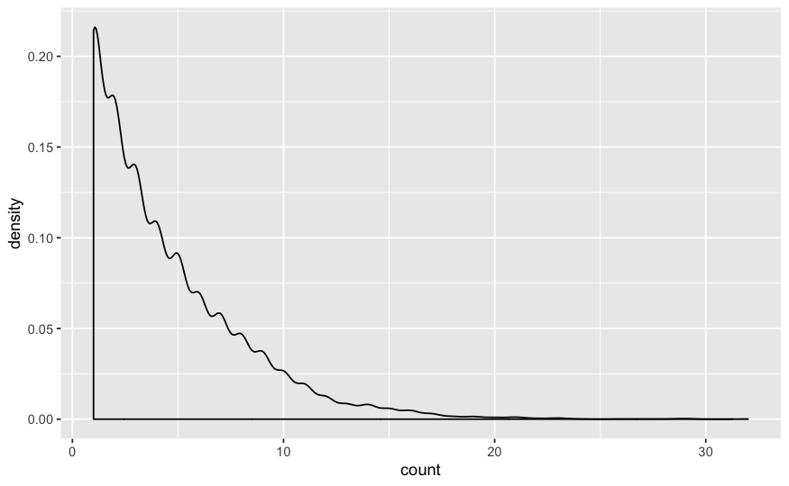

```r
library(ggplot2)
ggplot(data.frame(count = basketSizes)) +
  geom_density(aes(x=count))
```

El soporte tiene que ser menos al 20%, me ayuda a calibrar mejor

```r
# Mostrar las transacciones
#labels(groceries) # me das las etiqutas de las transacciones
colnames(groceries)[1:5] # me devuelve el nombre de los items
```

```
[1] "abrasive cleaner" "artif. sweetener" "baby cosmetics"   "baby food"
[5] "bags"
```

```r
# Mostrar un subconjunto de transacciones (p. ej. las cinco primeras)
inspect(groceries[1:5])
```

```
    items
[1] {citrus fruit,
     margarine,
     ready soups,
     semi-finished bread}
[2] {coffee,
     tropical fruit,
     yogurt}
[3] {whole milk}
[4] {cream cheese,
     meat spreads,
     pip fruit,
     yogurt}
[5] {condensed milk,
     long life bakery product,
     other vegetables,
     whole milk}
```

Me lo ordena alfabeticamente

El soporte es la proporcion de los itemsets

```r
# Mostrar el soporte (proporci?n de transacciones) de un item (p. ej. de los tres primeros)
itemFrequency(groceries[, 1:3])
```

```
abrasive cleaner artif. sweetener   baby cosmetics
    0.0035587189     0.0032536858     0.0006100661
```

Se muestran 3 productos.

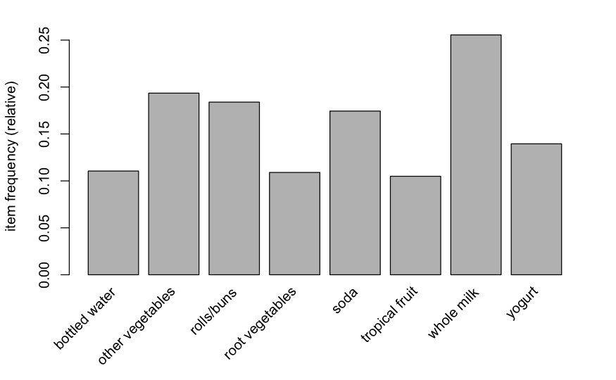

```r
# Visualizar el soporte de los items (p. ej. de aquellos items con una proporcion mayor a 0.10)
itemFrequencyPlot(groceries, support = 0.1)
```

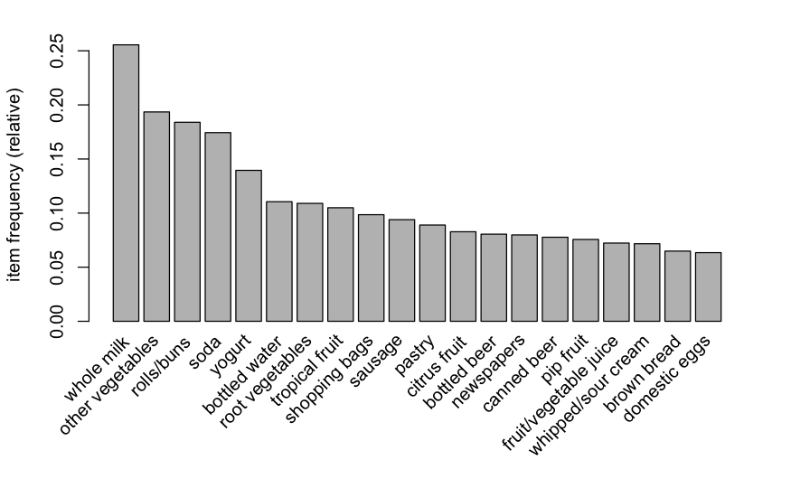

```r
# Visualizar el soporte de los items (p. ej.de los 20 ?tems con mayor soporte)
itemFrequencyPlot(groceries, topN = 20)
```

El que tiene menor frecuencia es menor a 0.10

```r
# Obtener los 20 items mas frecuents
groceriesFreq <- itemFrequency(groceries)
summary(groceriesFreq)
```

```
     Min.   1st Qu.    Median      Mean   3rd Qu.      Max.
0.0001017 0.0038637 0.0104728 0.0260915 0.0310117 0.2555160
```

```r
sum(groceriesFreq)
```

```
[1] 4.409456
```

Item mas frecuentes

```r
groceriesCount <- (groceriesFreq/sum(groceriesFreq))*sum(basketSizes)
summary(groceriesCount)
```

```
   Min. 1st Qu.  Median    Mean 3rd Qu.    Max.
    1.0    38.0   103.0   256.6   305.0  2513.0
```

```r
orderedgroceries <- sort(groceriesCount, decreasing = T)
orderedgroceries[1:20]
```

```
           whole milk      other vegetables            rolls/buns                  soda                yogurt
                 2513                  1903                  1809                  1715                  1372
        bottled water       root vegetables        tropical fruit         shopping bags               sausage
                 1087                  1072                  1032                   969                   924
               pastry          citrus fruit          bottled beer            newspapers           canned beer
                  875                   814                   792                   785                   764
            pip fruit fruit/vegetable juice    whipped/sour cream           brown bread         domestic eggs
                  744                   711                   705                   638                   624
```

Item menos frecuentes

```r
groceriesCount <- (groceriesFreq/sum(groceriesFreq))*sum(basketSizes)
summary(groceriesCount)
```

```
   Min. 1st Qu.  Median    Mean 3rd Qu.    Max.
    1.0    38.0   103.0   256.6   305.0  2513.0
```

```r
orderedgroceries <- sort(groceriesCount, decreasing = F)
orderedgroceries[1:20]
```

```
            baby food  sound storage medium preservation products                  bags       kitchen utensil
                    1                     1                     2                     4                     4
       baby cosmetics        frozen chicken        toilet cleaner       make up remover        salad dressing
                    6                     6                     7                     8                     8
               whisky               liqueur       rubbing alcohol            hair spray         frozen fruits
                    8                     9                    10                    11                    12
                cream           decalcifier                 honey      organic products  specialty vegetables
                   13                    15                    15                    16                    17
```

Los patrones estacionarios deben ser retirados : Ejemplo : los turrones de doña pepa, los panetones, son estacionales

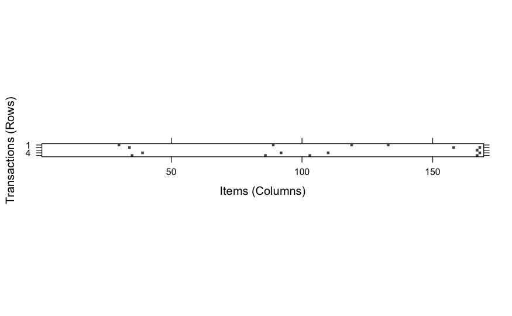

```r
# Visualizar la matriz de transacciones (p. ej. para las 5 primeras transacciones)
image(groceries[1:5])
```

Cuando hay un punto que se repita en todo la columna, podria ser estacionario

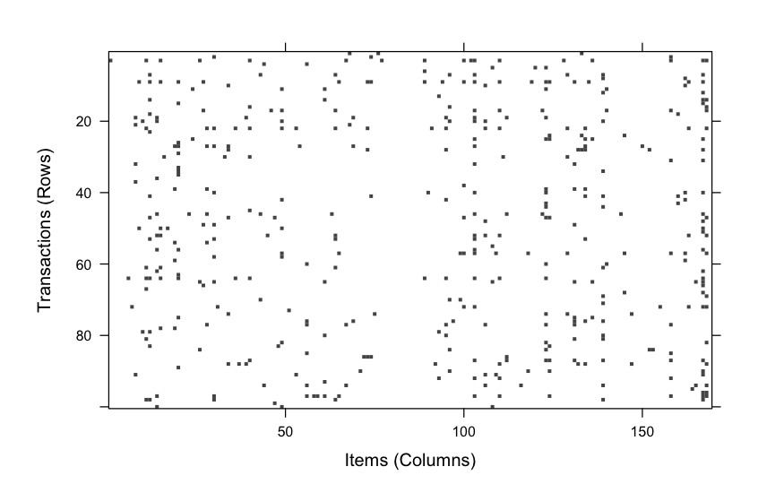

```r
# Visualizar la matriz de transacciones (p. ej. seleccionar al azar 100 transacciones)
image(sample(groceries, 100))
```

Se saca en forma aleatoria los puntos, y si hubiera una columna de color negro, es probable que sea estacionario #———————————————————————————- # Interpretaciones : # ——————————————————————————— # Los puntos deber?an verse dispersos con un patr?n aleatorio. # Buscar patrones no aleatorios: # - Si un ?tem aparece en todas las transacciones podr?a tratarse de informaci?n que no # corresponde a un item comprado. # - Si se ordenan los items por alg?n criterio, por ejemplo fecha de compra, podr?an # detectarse alg?n comportamiento estacional (Halloween, Navidad, etc.) #———————————————————————————–

#_______________________________________________________ # Paso 2: Entrenar el modelo con los datos #_______________________________________________________

```r
help(apriori)
```

parameter  
object of class APparameter or named list. The default behavior is to mine rules with minimum support of 0.1, minimum confidence of 0.8, maximum of 10 items (maxlen), and a maximal time for subset checking of 5 seconds (maxtime).

```r
apriori(groceries)
```

```
Apriori

Parameter specification:
```

|  | confidence | minval | smax | arem | aval | originalSupport | maxtime | support | minlen | maxlen | target | ext |
| --- | --- | --- | --- | --- | --- | --- | --- | --- | --- | --- | --- | --- |
|  | 0.8 | 0.1 | 1 | none | FALSE | TRUE | 5 | 0.1 | 1 | 10 | rules | FALSE |

```
Algorithmic control:
```

|  | filter | tree | heap | memopt | load | sort | verbose |
| --- | --- | --- | --- | --- | --- | --- | --- |
|  | 0.1 | TRUE | TRUE | FALSE | TRUE | 2 | TRUE |

```
Absolute minimum support count: 983

set item appearances ...[0 item(s)] done [0.00s].
set transactions ...[169 item(s), 9835 transaction(s)] done [0.01s].
sorting and recoding items ... [8 item(s)] done [0.00s].
creating transaction tree ... done [0.00s].
checking subsets of size 1 2 done [0.00s].
writing ... [0 rule(s)] done [0.00s].
creating S4 object  ... done [0.00s].
set of 0 rules
```

SOPORTE # - Pensar en el menor n?mero de transacciones que necesites para considerar que un patr?n # es interesante. Por ejemplo, si se argumenta que si se compra un art?culo dos veces al d?a # (alrededor de 60 veces en un mes), esto puede ser un patr?n interesante. A partir de ah?, # es posible calcular el nivel de apoyo necesario para encontrar s?lo las reglas que coincidan # con al menos ese n?mero de transacciones. Como 60 de 9835 es aprox. 0.006, se puede establecer # el soporte a partir de este valor.

CONFIANZA # - Determinar la confianza m?nima involucra realizar un balance muy delicado. Por un lado, si la # confianza es es demasiado baja, es posible obtener un n?mero abrumadoramente alto de reglas con # poca fiabilidad (p. ej. pa?ales de bebe son comprados junto con muchos productos). Por otro lado, # si se fija una confianza muy alta, se limitaran a las reglas que son obvias o inevitable, (p. ej. # pa?ales de bebe son comprados junto a biberones o leche para recien nacidos). # - El nivel de confianza m?nimo adecuado depende en gran medida de los objetivos del an?lisis. # Si se parte de un valor conservador, siempre se puede reducir para ampliar la b?squeda. # - Para este ejemplo se iniciar? con un umbral para la confianza de 0.25, esto indica que para que una # regla de asociaci?n se considere relevante deber?a ocurrir en al menos un 25% de las veces. Esto # ayudar?a a eliminar la mayor?a de reglas poco fiables, al mismo tiempo que permite un cierto margen # para incentivar el comportamiento del cliente con promociones espec?ficas. # - Adicionalmente al soporte y la confianza, ayuda fijar minlen = 2 para eliminar reglas que # contengan menos de dos ?tems. Esto previene obtener reglas poco interesantes que se generan porque un item # es comprado muy frecuentemente, por ejemplo {} -> whole milk. Esta regla cumple con el m?nimo de # soporte y confianza porque whole milk es comprada en m?s del 25% de las transacciones, pero # no brinda un insight accionable. #———————————————————————————–